# La tendance du baby boom

Ana Savard Université Laval 2026-12-11

## 1. Question de recherche et hypothèse

Le baby-boom est un événement qui a été très marquant pour l’histoire du Canada. Les enseignants au secondaire nous expliquaient comment la fin de la Seconde Guerre mondiale, l’amélioration des conditions de vie et l’euphorie générale de la population ont favorisé une augmentation des taux de natalité, créant ainsi une nouvelle génération : les baby-boomers. Selon Statistique Québec, cette génération s’étend de la fin de la Seconde Guerre mondiale jusqu’en 1965, en pleine période de prospérité (Québec, n.d.). Pour l’histoire canadienne et québécoise, cela a été un immense événement, mais le baby-boom a-t-il eu lieu dans les autres pays touchés par la guerre ? Ce travail tentera de répondre à la question suivante : est-ce que l’intensité de la Seconde Guerre mondiale a eu des effets sur le baby-boom pour les principaux acteurs du conflit ? En se basant sur les différentes sources, il est possible de s’imaginer que bien que la France, le Royaume-Uni, le Japon, l’Italie et l’Allemagne aient vécu la guerre plus directement que le Canada, cela n’empêche pas qu’ils aient connu, à leur rythme, une forme de baby-boom. Dans ce travail, les données recueillies couvriront la période de 1940 à 1970 afin d’avoir une vue d’ensemble de la vague de naissances. Il est important de mentionner que l’URSS ne sera pas incluse puisqu’il a été très difficile de trouver des données fiables et antérieures aux années 1950.

Durant l’étape de la recherche, je me suis servie de plusieurs outils pour faire la synthèse des références. Afin d’avoir un certain aperçu des sources disponibles, j’ai d’abord utilisé Consensus. Cela m’a permis de brosser un portrait assez large de la recherche sur le baby-boom. Lorsqu’une source était considérée comme intéressante, mais inaccessible via le site de Consensus, j’utilisais Sofia, le catalogue de la bibliothèque de l’Université Laval. En mettant les références dans son système, je pouvais donc avoir accès à la source proposée par Consensus. Je me suis aussi servie de Google Scholar avec Sofia, puisque ce ne sont pas toutes les références dans Google Scholar qui sont accessibles gratuitement. Je ne regardais pas nécessairement le nombre de citations de la source, mais puisque Google Scholar présente toutes les références qui pourraient porter sur le baby-boom, cela m’a permis d’aller en profondeur dans ma recherche. J’ai également fait usage de Word pour pouvoir prendre des notes. Enfin, j’ai eu recours à Zotero comme outil de gestion de références pour m’aider dans la liste des références à la fin du texte.

## 2. Collecte de données

La collecte fut beaucoup plus difficile que je ne l’imaginais. J’ai demandé à Claude, une intelligence artificielle (IA), de me proposer différents outils pour collecter des données. Malheureusement, comme je ne cherchais pas d’informations dans les journaux, je ne pouvais utiliser ni Factiva ni Eureka. Au départ, j’avais en tête le site Our World in Data, où l’on peut retrouver toutes les données statistiques à travers le monde. Toutefois, les informations concernant le taux de natalité pour ces cinq pays ne commençaient pas avant les années 1950, ce qui ne fonctionnait pas pour moi puisque je voulais avoir des données datant de la période de la guerre. J’ai ensuite redemandé à Claude de me proposer des idées d’outils, mais pour chaque pays, puisque ce ne sont pas tous les États qui utilisent le même site pour y mettre leurs données.

Finalement, à force de faire des recherches d’outils, je suis tombée sur la plateforme Statista où l’on peut trouver plusieurs tableaux et données statistiques pour plusieurs pays et portant sur différents sujets. Normalement, la consultation est payante, mais en tant que membre de l’Université Laval, j’ai eu le droit d’y avoir accès gratuitement. Avec Statista, j’ai pu choisir mes différents acteurs et extraire leurs données avec la période souhaitée. Cependant, j’ai longtemps cherché des données sur l’URSS et il m’était impossible d’obtenir des données antérieures à 1950 ou de trouver le taux de fécondité par femme (la majorité des données représentaient le nombre de naissances pour 1 000 femmes, ce qui ne concordait pas avec l’unité de mesure des autres États).

## 3. Analyse et visualisation des données

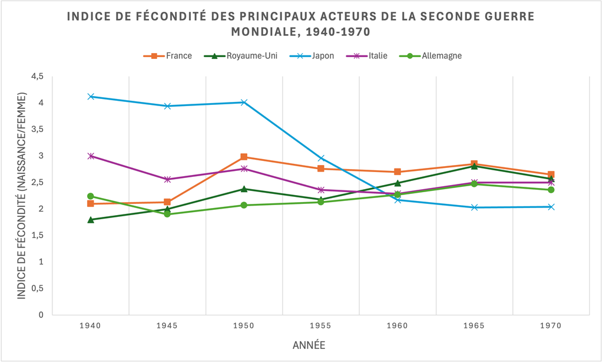

**Source:** Statista.com

J’ai utilisé Excel pour réaliser ce graphique puisque c’était l’outil avec lequel j’étais le plus à l’aise. J’ai longtemps essayé de comprendre comment transférer mes données dans le logiciel, mais après plusieurs tentatives, j’ai décidé de prendre chaque donnée de ma période d’étude et de les mettre directement dans Excel. J’ai ensuite créé mon graphique avec les variables que je voulais et j’ai changé son apparence pour le rendre plus facile à comprendre. Suite à cela, je l’ai transféré dans mon dossier projet sur Positron et, après une demi-heure, j’ai été capable de le faire apparaitre dans mon texte. Comme mentionné dans la première section du travail, j’ai aussi utilisé Zotero pour m’aider à faire la liste des références et à mettre toutes mes sources dans le même style bibliographique.

## 4. Discussion

Je crois que j’ai beaucoup plus appris en me servant des outils qu’en analysant des données du baby-boom. Je n’ai jamais été quelqu’un qui utilisait beaucoup la technologie, puisque j’aime bien tout faire par moi-même, en commençant par la bibliographie. Je dois toutefois être honnête, je me suis beaucoup servie de Claude pour qu’il m’explique le fonctionnement des outils et comment mettre mes données dans mon modèle Markdown. Toutefois, je tiens à préciser que ce n’est pas Claude qui a écrit ce travail, mais bel et bien moi. J’ai découvert Zotero et, pour être honnête, j’adore cela, même si ça peut être un peu compliqué au début. Je pense qu’on gagne énormément de temps au moment de faire notre bibliographie. Bien que l’on doive passer environ cinq minutes à le comprendre, surtout si on n’utilise pas les explications de l’IA, je crois que ce sera un outil que je vais utiliser dans le futur. Ce qui est intéressant avec Zotero, c’est qu’il est totalement gratuit, que l’on soit étudiant universitaire ou non, ce qui permet à vraiment tout le monde de l’utiliser. De plus, au départ, je ne comprenais pas comment mettre des liens internet sur Zotero, mais ce qui est pratique, c’est que l’on peut l’installer directement sur son serveur web et l’avoir à sa disposition (pour ma propre version de Zotero, ça fonctionnait).

En ce qui concerne Sofia et Google Scholar, ce n’était pas une immense découverte pour moi puisque je les utilise de façon quotidienne pour mes travaux scolaires. Je suis une grande utilisatrice de Sofia, et je redoute le jour où je vais obtenir mon diplôme puisque je n’aurai plus accès à son contenu. Bien sûr, Google Scholar sera là, mais bien que l’on puisse trouver énormément de références, la plupart sont inaccessibles, ce qui n’arrange pas les choses. Je crois que Consensus est un bon outil pour dresser un portrait général d’une question, mais avec mon utilisation pour le baby-boom, plusieurs de ses références ne m’étaient d’aucune utilité. Comme j’ai encore accès à l’outil jusqu’à la fin de mes études, je devrai refaire des tests pour voir si je l’adopterai ou non. En ce qui concerne Statista, je crois que c’est une bonne source si on a besoin d’avoir accès à des statistiques de partout dans le monde concernant différents sujets. Le problème, c’est qu’il est certes accessible à tous, mais si la personne doit télécharger les données, elle a besoin d’un compte (à moins d’être membre d’une université affiliée au site web). Pour le logiciel Excel, j’ai encore une fois dû utiliser l’IA pour comprendre comment il fonctionnait. Son interface est très complexe, mais une fois le tutoriel regardé, il est assez flexible. J’ai pu tout faire avec le logiciel et changer les attributs pour mettre ce que je voulais. Toutefois, ce n’est pas pour rien que certaines écoles offrent des formations pour comprendre le fonctionnement de ce logiciel.

Au bout du compte, je ne me suis pas vraiment basée sur mes valeurs lors de l’utilisation de ces outils. Je sais que l’usage de l’intelligence artificielle est très partagé : certains y voient une menace pour l’environnement en raison de sa consommation d’eau, alors que pour d’autres, c’est un outil indispensable. Je reconnais que plusieurs personnes abusent de son utilisation, mais dans mon cas, je dois admettre qu’elle a été très utile pour m’expliquer les différentes fonctions des outils que j’ai utilisés. Bien que j’aie choisi les outils par moi-même, je me basais souvent sur ses explications pour comprendre leur fonctionnement. Je ne me suis pas basée sur mes valeurs, mais chaque outil que j’ai utilisé a été profitable et a été capable de s’adapter aux autres. Je recommande donc chacun des outils présents dans ce travail.

## 5. Références

“France: Fertility Rate 1800-2020.” n.d. In *Statista*. Accessed November 26, 2026. https://www.statista.com/statistics/1033137/fertility-rate-france-1800-2020/.

“Germany: Fertility Rate 1800-2020.” n.d. In *Statista*. Accessed November 26, 2026. https://www.statista.com/statistics/1033102/fertility-rate-germany-1800-2020/.

“Japan: Fertility Rate 1800-2020.” n.d. In *Statista*. Accessed November 26, 2026. https://www.statista.com/statistics/1033777/fertility-rate-japan-1800-2020/?

Pool, Ian. 2007. “The Baby Boom in New Zealand and Other Western Developed Countries.” *Journal of Population Research* 24 (2): 141–61. https://doi.org/10.1007/BF03031928.

Québec, Institut de la statistique du. n.d. “Naissances Et Taux de Natalité, Québec, 1900-2025.” In *Institut de La Statistique Du Québec*. Accessed November 26, 2026. https://statistique.quebec.ca/fr/produit/tableau/naissances-et-taux-de-natalite-quebec.

Sánchez-Barricarte, Jesús J. 2018. “Measuring and Explaining the Baby Boom in the Developed World in the Mid-Twentieth Century.” *Demographic Research* 38 (March): 1189–240. https://doi.org/10.4054/DemRes.2018.38.40.

“United Kingdom: Fertility Rate 1800-2020.” n.d. In *Statista*. Accessed November 26, 2026. https://www.statista.com/statistics/1033074/fertility-rate-uk-1800-2020/.

Van Bavel, Jan, and David S. Reher. 2013. “The Baby Boom and Its Causes: What We Know and What We Need to Know.” *Population and Development Review* 39 (2): 257–88. https://doi.org/10.1111/j.1728-4457.2013.00591.x.